# Introduction

1. Business Understanding
2. Data Understanding
3. Data Preparation
4. Modelling
5. Evaluation
6. Deployment

[figure not shown]

# Business Understanding

In this project, a mail-order sales company in Germany is interested in identifying **segments of the general population to target** with their marketing in order to grow. The objective is to identify which individuals are most likely to respond to the campaign and become customers of the mail-order company.

In this section, I will first focus on identifying the parts on the population that **best describe the core customer base** of the company **using customer segmentation**.

# Data Understanding

In this step, I will focus on understanding the Arvato and Germany Demographics data. I will do this as follows:

1. Go step by step through the Data Dictionaries: DIAS Attributes - Values 2017 and DIAS Information Levels - Attributes 2017 sheets.
2. Create Pandas Profiling reports and analyse them i.e. Geramany Pop Demographics Report and Customer Demographics Report
3. Note down **observations** and **action points** from Analysis

## Load Datasets

```python
import pandas as pd
import numpy as np
import pandas_profiling as pp
import matplotlib.pyplot as plt
import altair as alt

pd.set_option("display.max_columns",50)
%matplotlib inline

home_dir = '../'
data_dir = home_dir + 'data/'
raw_dir = data_dir + 'raw/'
processed_dir = data_dir + 'processed/'
```

```python
%%time
customer_demographics = pd.read_csv(raw_dir + 'Udacity_CUSTOMERS_052018.csv', sep=';', low_memory=False)
population_demographics = pd.read_csv(raw_dir + 'Udacity_AZDIAS_052018.csv', sep=';', low_memory=False)
```

```
Wall time: 39.7 s
```

## Generate Pandas Profiling Reports

```python
kwargs = dict(correlations={
        "pearson": {"calculate": False, 'warn_high_correlations': True},
        "spearman": {"calculate": False, 'warn_high_correlations': True},
        "kendall": {"calculate": False, 'warn_high_correlations': False},
        "phi_k": {"calculate": False, 'warn_high_correlations': False},
        "cramers": {"calculate": False, 'warn_high_correlations': False},
    }, missing_diagrams=None, interactions=None)
```

```python
%%time
pp.ProfileReport(customer_demographics, title='Arvato Customer Demographics', **kwargs).to_file(raw_dir + 'customer_demographics.html')
```

```
Wall time: 3min 34s
```

```python
%%time
pp.ProfileReport(population_demographics, title='Germany Population Demographics', **kwargs).to_file(raw_dir + 'population_demographics.html')
```

```
Wall time: 12min 56s
```

## Observations

1. The Demographics data uses **PLZ8 data**. You can find more info in it [here](https://www.regionale-marktdaten.de/plz8/) or [here](https://ddsgeo.com/download/flyer/PLZ8_eng_Flyer.pdf).
2. It also uses **grid data**. You can find more info on this dataset [here](https://www.regionale-marktdaten.de/az-deutschland-raster/).
3. It also has records of Information Level RR1_ID, RR3_ID and RR4_ID which are all different **spatial levels**. RR3_ID and RR4_ID are all associated with the **microcell level**, however I could not find a concise explanation for this spatial level beyond a small geographic area covered by a cellular carrier or some other transmission system.
4. Many features have a large proportion of unknown values i.e. -1 or 0
5. The features are too many to manually asses and drop.

## Action Points

1. Feed datasets with minimal data cleanin and transformation to algorithms to discover important features.

# Data Preparation

In this section, I clean and transform the Demographics data in preparation for clustering with HDBSCAN

```python
from sklearn.preprocessing import MinMaxScaler, FunctionTransformer, Normalizer, LabelEncoder
```

```python
all_known_columns = "AGER_TYP,ALTERSKATEGORIE_GROB,ALTER_HH,ANREDE_KZ,ANZ_HAUSHALTE_AKTIV,ANZ_HH_TITEL,ANZ_PERSONEN,ANZ_TITEL,BALLRAUM,BIP_FLAG,CAMEO_DEUG_2015,CAMEO_DEU_2015,CAMEO_DEUINTL_2015,CJT_GESAMTTYP,D19_BANKEN_ANZ_12,D19_BANKEN_ANZ_24,D19_BANKEN_DATUM,D19_BANKEN_DIREKT_RZ,D19_BANKEN_GROSS_RZ,D19_BANKEN_LOKAL_RZ,D19_BANKEN_OFFLINE_DATUM,D19_BANKEN_ONLINE_DATUM,D19_BANKEN_ONLINE_QUOTE_12,D19_BANKEN_REST_RZ,D19_BEKLEIDUNG_GEH_RZ,D19_BEKLEIDUNG_REST_RZ,D19_BILDUNG_RZ,D19_BIO_OEKO_RZ,D19_BUCH_RZ,D19_DIGIT_SERV_RZ,D19_DROGERIEARTIKEL_RZ,D19_ENERGIE_RZ,D19_FREIZEIT_RZ,D19_GARTEN_RZ,D19_GESAMT_ANZ_12,D19_GESAMT_ANZ_24,D19_GESAMT_DATUM,D19_GESAMT_OFFLINE_DATUM,D19_GESAMT_ONLINE_DATUM,D19_GESAMT_ONLINE_QUOTE_12,D19_HANDWERK_RZ,D19_HAUS_DEKO_RZ,D19_KINDERARTIKEL_RZ,D19_KONSUMTYP,D19_KK_KUNDENTYP,D19_KOSMETIK_RZ,D19_LEBENSMITTEL_RZ,D19_LOTTO_RZ,D19_NAHRUNGSERGAENZUNG_RZ,D19_RATGEBER_RZ,D19_REISEN_RZ,D19_SAMMELARTIKEL_RZ,D19_SCHUHE_RZ,D19_SONSTIGE_RZ,D19_TECHNIK_RZ,D19_TELKO_ANZ_12,D19_TELKO_ANZ_24,D19_TELKO_DATUM,D19_TELKO_MOBILE_RZ,D19_TELKO_OFFLINE_DATUM,D19_TELKO_ONLINE_DATUM,D19_TELKO_REST_RZ,D19_TIERARTIKEL_RZ,D19_VERSAND_ANZ_12,D19_VERSAND_ANZ_24,D19_VERSAND_DATUM,D19_VERSAND_OFFLINE_DATUM,D19_VERSAND_ONLINE_DATUM,D19_VERSAND_ONLINE_QUOTE_12,D19_VERSAND_REST_RZ,D19_VERSICHERUNGEN_RZ,D19_VERSI_ANZ_12,D19_VERSI_ANZ_24,D19_VOLLSORTIMENT_RZ,D19_WEIN_FEINKOST_RZ,EWDICHTE,FINANZTYP,FINANZ_ANLEGER,FINANZ_HAUSBAUER,FINANZ_MINIMALIST,FINANZ_SPARER,FINANZ_UNAUFFAELLIGER,FINANZ_VORSORGER,GEBAEUDETYP,GEBAEUDETYP_RASTER,GEBURTSJAHR,GFK_URLAUBERTYP,GEOSCORE_KLS7,GREEN_AVANTGARDE,HAUSHALTSSTRUKTUR,HEALTH_TYP,HH_EINKOMMEN_SCORE,INNENSTADT,KBA05_ALTER1,KBA05_ALTER2,KBA05_ALTER3,KBA05_ALTER4,KBA05_ANHANG,KBA05_ANTG1,KBA05_ANTG2,KBA05_ANTG3,KBA05_ANTG4,KBA05_AUTOQUOT,KBA05_BAUMAX,KBA05_CCM1,KBA05_CCM2,KBA05_CCM3,KBA05_CCM4,KBA05_DIESEL,KBA05_FRAU,KBA05_GBZ,KBA05_HERST1,KBA05_HERST2,KBA05_HERST3,KBA05_HERST4,KBA05_HERST5,KBA05_HERSTTEMP,KBA05_KRSAQUOT,KBA05_KRSHERST1,KBA05_KRSHERST2,KBA05_KRSHERST3,KBA05_KRSKLEIN,KBA05_KRSOBER,KBA05_KRSVAN,KBA05_KRSZUL,KBA05_KW1,KBA05_KW2,KBA05_KW3,KBA05_MAXAH,KBA05_MAXBJ,KBA05_MAXHERST,KBA05_MAXSEG,KBA05_MAXVORB,KBA05_MOD1,KBA05_MOD2,KBA05_MOD3,KBA05_MOD4,KBA05_MOD8,KBA05_MODTEMP,KBA05_MOTOR,KBA05_MOTRAD,KBA05_SEG1,KBA05_SEG10,KBA05_SEG2,KBA05_SEG3,KBA05_SEG4,KBA05_SEG5,KBA05_SEG6,KBA05_SEG7,KBA05_SEG8,KBA05_SEG9,KBA05_VORB0,KBA05_VORB1,KBA05_VORB2,KBA05_ZUL1,KBA05_ZUL2,KBA05_ZUL3,KBA05_ZUL4,KBA13_ALTERHALTER_30,KBA13_ALTERHALTER_45,KBA13_ALTERHALTER_60,KBA13_ALTERHALTER_61,KBA13_ANZAHL_PKW,KBA13_AUDI,KBA13_AUTOQUOTE,KBA13_BJ_1999,KBA13_BJ_2000,KBA13_BJ_2004,KBA13_BJ_2006,KBA13_BJ_2008,KBA13_BJ_2009,KBA13_BMW,KBA13_CCM_1000,KBA13_CCM_1200,KBA13_CCM_1400,KBA13_CCM_0_1400,KBA13_CCM_1500,KBA13_CCM_1400_2500,KBA13_CCM_1600,KBA13_CCM_1800,KBA13_CCM_2000,KBA13_CCM_2500,KBA13_CCM_2501,KBA13_CCM_3000,KBA13_CCM_3001,KBA13_FAB_ASIEN,KBA13_FAB_SONSTIGE,KBA13_FIAT,KBA13_FORD,KBA13_HALTER_20,KBA13_HALTER_25,KBA13_HALTER_30,KBA13_HALTER_35,KBA13_HALTER_40,KBA13_HALTER_45,KBA13_HALTER_50,KBA13_HALTER_55,KBA13_HALTER_60,KBA13_HALTER_65,KBA13_HALTER_66,KBA13_HERST_ASIEN,KBA13_HERST_AUDI_VW,KBA13_HERST_BMW_BENZ,KBA13_HERST_EUROPA,KBA13_HERST_FORD_OPEL,KBA13_HERST_SONST,KBA13_KMH_110,KBA13_KMH_140,KBA13_KMH_180,KBA13_KMH_0_140,KBA13_KMH_140_210,KBA13_KMH_211,KBA13_KMH_250,KBA13_KMH_251,KBA13_KRSAQUOT,KBA13_KRSHERST_AUDI_VW,KBA13_KRSHERST_BMW_BENZ,KBA13_KRSHERST_FORD_OPEL,KBA13_KRSSEG_KLEIN,KBA13_KRSSEG_OBER,KBA13_KRSSEG_VAN,KBA13_KRSZUL_NEU,KBA13_KW_30,KBA13_KW_40,KBA13_KW_50,KBA13_KW_60,KBA13_KW_0_60,KBA13_KW_70,KBA13_KW_61_120,KBA13_KW_80,KBA13_KW_90,KBA13_KW_110,KBA13_KW_120,KBA13_KW_121,KBA13_MAZDA,KBA13_MERCEDES,KBA13_MOTOR,KBA13_NISSAN,KBA13_OPEL,KBA13_PEUGEOT,KBA13_RENAULT,KBA13_SEG_GELAENDEWAGEN,KBA13_SEG_GROSSRAUMVANS,KBA13_SEG_KLEINST,KBA13_SEG_KLEINWAGEN,KBA13_SEG_KOMPAKTKLASSE,KBA13_SEG_MINIVANS,KBA13_SEG_MINIWAGEN,KBA13_SEG_MITTELKLASSE,KBA13_SEG_OBEREMITTELKLASSE,KBA13_SEG_OBERKLASSE,KBA13_SEG_SONSTIGE,KBA13_SEG_SPORTWAGEN,KBA13_SEG_UTILITIES,KBA13_SEG_VAN,KBA13_SEG_WOHNMOBILE,KBA13_SITZE_4,KBA13_SITZE_5,KBA13_SITZE_6,KBA13_TOYOTA,KBA13_VORB_0,KBA13_VORB_1,KBA13_VORB_1_2,KBA13_VORB_2,KBA13_VORB_3,KBA13_VW,KKK,KONSUMNAEHE,LP_FAMILIE_FEIN,LP_FAMILIE_GROB,LP_LEBENSPHASE_FEIN,LP_LEBENSPHASE_GROB,LP_STATUS_FEIN,LP_STATUS_GROB,MIN_GEBAEUDEJAHR,MOBI_REGIO,NATIONALITAET_KZ,ONLINE_AFFINITAET,ORTSGR_KLS9,OST_WEST_KZ,PLZ8_ANTG1,PLZ8_ANTG2,PLZ8_ANTG3,PLZ8_ANTG4,PLZ8_BAUMAX,PLZ8_GBZ,PLZ8_HHZ,PRAEGENDE_JUGENDJAHRE,REGIOTYP,RELAT_AB,RETOURTYP_BK_S,SEMIO_DOM,SEMIO_ERL,SEMIO_FAM,SEMIO_KAEM,SEMIO_KRIT,SEMIO_KULT,SEMIO_LUST,SEMIO_MAT,SEMIO_PFLICHT,SEMIO_RAT,SEMIO_REL,SEMIO_SOZ,SEMIO_TRADV,SEMIO_VERT,SHOPPER_TYP,SOHO_FLAG,TITEL_KZ,VERS_TYP,WOHNDAUER_2008,WOHNLAGE,WACHSTUMSGEBIET_NB,W_KEIT_KIND_HH,ZABEOTYP".split(',')

numerical_features = 'ANZ_HAUSHALTE_AKTIV,ANZ_HH_TITEL,ANZ_PERSONEN,ANZ_TITEL,KBA13_ANZAHL_PKW,clusters_prob'.split(',')
ordinal_features = "BALLRAUM,CAMEO_DEUG_2015,D19_BANKEN_ANZ_12,D19_BANKEN_ANZ_24,D19_BANKEN_DATUM,D19_BANKEN_DIREKT_RZ,D19_BANKEN_GROSS_RZ,D19_BANKEN_LOKAL_RZ,D19_BANKEN_OFFLINE_DATUM,D19_BANKEN_ONLINE_DATUM,D19_BANKEN_ONLINE_QUOTE_12,D19_BANKEN_REST_RZ,D19_BEKLEIDUNG_GEH_RZ,D19_BEKLEIDUNG_REST_RZ,D19_BILDUNG_RZ,D19_BIO_OEKO_RZ,D19_BUCH_RZ,D19_DIGIT_SERV_RZ,D19_DROGERIEARTIKEL_RZ,D19_ENERGIE_RZ,D19_FREIZEIT_RZ,D19_GARTEN_RZ,D19_GESAMT_ANZ_12,D19_GESAMT_ANZ_24,D19_GESAMT_DATUM,D19_GESAMT_OFFLINE_DATUM,D19_GESAMT_ONLINE_DATUM,D19_GESAMT_ONLINE_QUOTE_12,D19_HANDWERK_RZ,D19_HAUS_DEKO_RZ,D19_KINDERARTIKEL_RZ,D19_KOSMETIK_RZ,D19_LEBENSMITTEL_RZ,D19_LOTTO_RZ,D19_NAHRUNGSERGAENZUNG_RZ,D19_RATGEBER_RZ,D19_REISEN_RZ,D19_SAMMELARTIKEL_RZ,D19_SCHUHE_RZ,D19_SONSTIGE_RZ,D19_TECHNIK_RZ,D19_TELKO_ANZ_12,D19_TELKO_ANZ_24,D19_TELKO_DATUM,D19_TELKO_MOBILE_RZ,D19_TELKO_OFFLINE_DATUM,D19_TELKO_ONLINE_DATUM,D19_TELKO_REST_RZ,D19_TIERARTIKEL_RZ,D19_VERSAND_ANZ_12,D19_VERSAND_ANZ_24,D19_VERSAND_DATUM,D19_VERSAND_OFFLINE_DATUM,D19_VERSAND_ONLINE_DATUM,D19_VERSAND_ONLINE_QUOTE_12,D19_VERSAND_REST_RZ,D19_VERSICHERUNGEN_RZ,D19_VERSI_ANZ_12,D19_VERSI_ANZ_24,EWDICHTE,FINANZ_ANLEGER,FINANZ_HAUSBAUER,FINANZ_MINIMALIST,FINANZ_SPARER,FINANZ_UNAUFFAELLIGER,FINANZ_VORSORGER,GEOSCORE_KLS7,HH_EINKOMMEN_SCORE,INNENSTADT,KBA05_ALTER1,KBA05_ALTER2,KBA05_ALTER3,KBA05_ALTER4,KBA05_ANHANG,KBA05_ANTG1,KBA05_ANTG2,KBA05_ANTG3,KBA05_ANTG4,KBA05_AUTOQUOT,KBA05_BAUMAX,KBA05_CCM1,KBA05_CCM2,KBA05_CCM3,KBA05_CCM4,KBA05_DIESEL,KBA05_FRAU,KBA05_GBZ,KBA05_HERST1,KBA05_HERST2,KBA05_HERST3,KBA05_HERST4,KBA05_HERST5,KBA05_KRSAQUOT,KBA05_KRSHERST1,KBA05_KRSHERST2,KBA05_KRSHERST3,KBA05_KRSKLEIN,KBA05_KRSOBER,KBA05_KRSVAN,KBA05_KRSZUL,KBA05_KW1,KBA05_KW2,KBA05_KW3,KBA05_MAXAH,KBA05_MAXBJ,KBA05_MAXHERST,KBA05_MAXSEG,KBA05_MAXVORB,KBA05_MOD1,KBA05_MOD2,KBA05_MOD3,KBA05_MOD4,KBA05_MOD8,KBA05_MOTOR,KBA05_MOTRAD,KBA05_SEG1,KBA05_SEG10,KBA05_SEG2,KBA05_SEG3,KBA05_SEG4,KBA05_SEG5,KBA05_SEG6,KBA05_SEG7,KBA05_SEG8,KBA05_SEG9,KBA05_VORB0,KBA05_VORB1,KBA05_VORB2,KBA05_ZUL1,KBA05_ZUL2,KBA05_ZUL3,KBA05_ZUL4,KBA13_ALTERHALTER_30,KBA13_ALTERHALTER_45,KBA13_ALTERHALTER_60,KBA13_ALTERHALTER_61,KBA13_AUDI,KBA13_AUTOQUOTE,KBA13_BJ_1999,KBA13_BJ_2000,KBA13_BJ_2004,KBA13_BJ_2006,KBA13_BJ_2008,KBA13_BJ_2009,KBA13_BMW,KBA13_CCM_1000,KBA13_CCM_1200,KBA13_CCM_1400,KBA13_CCM_0_1400,KBA13_CCM_1500,KBA13_CCM_1400_2500,KBA13_CCM_1600,KBA13_CCM_1800,KBA13_CCM_2000,KBA13_CCM_2500,KBA13_CCM_2501,KBA13_CCM_3000,KBA13_CCM_3001,KBA13_FAB_ASIEN,KBA13_FAB_SONSTIGE,KBA13_FIAT,KBA13_FORD,KBA13_HALTER_20,KBA13_HALTER_25,KBA13_HALTER_30,KBA13_HALTER_35,KBA13_HALTER_40,KBA13_HALTER_45,KBA13_HALTER_50,KBA13_HALTER_55,KBA13_HALTER_60,KBA13_HALTER_65,KBA13_HALTER_66,KBA13_HERST_ASIEN,KBA13_HERST_AUDI_VW,KBA13_HERST_BMW_BENZ,KBA13_HERST_EUROPA,KBA13_HERST_FORD_OPEL,KBA13_HERST_SONST,KBA13_KMH_110,KBA13_KMH_140,KBA13_KMH_180,KBA13_KMH_0_140,KBA13_KMH_140_210,KBA13_KMH_211,KBA13_KMH_250,KBA13_KMH_251,KBA13_KRSAQUOT,KBA13_KRSHERST_AUDI_VW,KBA13_KRSHERST_BMW_BENZ,KBA13_KRSHERST_FORD_OPEL,KBA13_KRSSEG_KLEIN,KBA13_KRSSEG_OBER,KBA13_KRSSEG_VAN,KBA13_KRSZUL_NEU,KBA13_KW_30,KBA13_KW_40,KBA13_KW_50,KBA13_KW_60,KBA13_KW_0_60,KBA13_KW_70,KBA13_KW_61_120,KBA13_KW_80,KBA13_KW_90,KBA13_KW_110,KBA13_KW_120,KBA13_KW_121,KBA13_MAZDA,KBA13_MERCEDES,KBA13_MOTOR,KBA13_NISSAN,KBA13_OPEL,KBA13_PEUGEOT,KBA13_RENAULT,KBA13_SEG_GELAENDEWAGEN,KBA13_SEG_GROSSRAUMVANS,KBA13_SEG_KLEINST,KBA13_SEG_KLEINWAGEN,KBA13_SEG_KOMPAKTKLASSE,KBA13_SEG_MINIVANS,KBA13_SEG_MINIWAGEN,KBA13_SEG_MITTELKLASSE,KBA13_SEG_OBEREMITTELKLASSE,KBA13_SEG_OBERKLASSE,KBA13_SEG_SONSTIGE,KBA13_SEG_SPORTWAGEN,KBA13_SEG_UTILITIES,KBA13_SEG_VAN,KBA13_SEG_WOHNMOBILE,KBA13_SITZE_4,KBA13_SITZE_5,KBA13_SITZE_6,KBA13_TOYOTA,KBA13_VORB_0,KBA13_VORB_1,KBA13_VORB_1_2,KBA13_VORB_2,KBA13_VORB_3,KBA13_VW,KKK,KONSUMNAEHE,LP_STATUS_GROB,MOBI_REGIO,NATIONALITAET_KZ,ONLINE_AFFINITAET,ORTSGR_KLS9,PLZ8_ANTG1,PLZ8_ANTG2,PLZ8_ANTG3,PLZ8_ANTG4,PLZ8_BAUMAX,PLZ8_GBZ,PLZ8_HHZ,REGIOTYP,RELAT_AB,SEMIO_DOM,SEMIO_ERL,SEMIO_FAM,SEMIO_KAEM,SEMIO_KRIT,SEMIO_KULT,SEMIO_LUST,SEMIO_MAT,SEMIO_PFLICHT,SEMIO_RAT,SEMIO_REL,SEMIO_SOZ,SEMIO_TRADV,SEMIO_VERT,WOHNDAUER_2008,WACHSTUMSGEBIET_NB,W_KEIT_KIND_HH".split(',')

# Columns that require Feature Corrections
incorrect_ordinal_0 = "D19_BANKEN_DIREKT_RZ,D19_BANKEN_GROSS_RZ,D19_BANKEN_LOKAL_RZ,D19_HANDWERK_RZ,D19_HAUS_DEKO_RZ,D19_KINDERARTIKEL_RZ,D19_KOSMETIK_RZ,D19_LEBENSMITTEL_RZ,D19_LOTTO_RZ,D19_NAHRUNGSERGAENZUNG_RZ,D19_RATGEBER_RZ,D19_REISEN_RZ,D19_SAMMELARTIKEL_RZ,D19_SCHUHE_RZ,D19_SONSTIGE_RZ,D19_TECHNIK_RZ,D19_TELKO_MOBILE_RZ,D19_TELKO_REST_RZ,D19_TIERARTIKEL_RZ,D19_VERSAND_REST_RZ,D19_VERSICHERUNGEN_RZ,D19_VOLLSORTIMENT_RZ,D19_WEIN_FEINKOST_RZ,HH_EINKOMMEN_SCORE".split(',')
incorrect_ordinal_9_neg1 = "KBA05_ALTER1,KBA05_ALTER2,KBA05_ALTER3,KBA05_ALTER4,KBA05_ANHANG,KBA05_AUTOQUOT,KBA05_CCM1,KBA05_CCM2,KBA05_CCM3,KBA05_CCM4,KBA05_DIESEL,KBA05_FRAU,KBA05_HERST1,KBA05_HERST2,KBA05_HERST3,KBA05_HERST4,KBA05_HERST5,KBA05_HERSTTEMP,KBA05_KRSAQUOT,KBA05_KRSHERST1,KBA05_KRSHERST2,KBA05_KRSHERST3,KBA05_KRSKLEIN,KBA05_KRSOBER,KBA05_KRSVAN,KBA05_KRSZUL,KBA05_KW1,KBA05_KW2,KBA05_KW3,KBA05_MAXAH,KBA05_MAXBJ,KBA05_MAXHERST,KBA05_MAXSEG,KBA05_MAXVORB,KBA05_MOD1,KBA05_MOD2,KBA05_MOD3,KBA05_MOD4,KBA05_MOD8,KBA05_MODTEMP,KBA05_MOTOR,KBA05_MOTRAD,KBA05_SEG1,KBA05_SEG10,KBA05_SEG2,KBA05_SEG3,KBA05_SEG4,KBA05_SEG5,KBA05_SEG6,KBA05_SEG7,KBA05_SEG8,KBA05_SEG9,KBA05_VORB0,KBA05_VORB1,KBA05_VORB2,KBA05_ZUL1,KBA05_ZUL2,KBA05_ZUL3,KBA05_ZUL4,RELAT_AB,SEMIO_DOM,SEMIO_ERL,SEMIO_FAM,SEMIO_KAEM,SEMIO_KRIT,SEMIO_KULT,SEMIO_LUST,SEMIO_MAT,SEMIO_PFLICHT,SEMIO_RAT,SEMIO_REL,SEMIO_SOZ,SEMIO_TRADV,SEMIO_VERT,ZABEOTYP".split(',')
```

```python
viz_df = pd.DataFrame({'Features': ['Ordinal Features','Numerical Features','Nominal Features'], 'Counts': [len(ordinal_features), len(numerical_features)+54, len(all_known_columns)-len(ordinal_features)-(len(numerical_features)+3)]})
bars = alt.Chart(viz_df).mark_bar().encode(y=alt.Y('Features:N', title='Feature Type'), x=alt.X('Counts', title='No of Features')).properties(width=600, height=150, title='Histogram of Feature Types')
text = bars.mark_text(
    align='right',
    baseline='middle',
    dx= -5,  # Nudges text to right so it doesn't appear on top of the bar
    color='white' ,
    thickness=12
).encode(
    text='Counts:Q'
)

bars + text
```

[interactive chart not shown]

```python
# Identifying columns that have more than 90% nulls
proportion_missing = population_demographics.isna().sum()/population_demographics.shape[0]
missing_data_cols = proportion_missing.reset_index().sort_values(by=0, ascending=False).rename(columns={0:'Missing_Proportion'}).query("Missing_Proportion > 0.9")['index'].tolist()

customer_proportion_missing = customer_demographics.isna().sum()/customer_demographics.shape[0]
missing_data_cols_cust = customer_proportion_missing.reset_index().sort_values(by=0, ascending=False).rename(columns={0:'Missing_Proportion'}).query("Missing_Proportion > 0.9")['index'].tolist()

assert missing_data_cols == missing_data_cols_cust, "Columns missing 90% of their data in the Customer and Population dataset should be the same"
```

```python
def clean_transform_demographics_data(demographics_df, missing_data_cols_, customer_data=True):
    """
    This method cleans and transforms the demographics data. It takes the following steps:
        1. Drop unneeded columns
        2. Peform Label Encoding on columns that represent Year and on String/Object columns
        3. Perform feature scaling on specific features
        4. Fill all nulls with -1. (This represents Unknown for most features)

    :param demographics_df:
    :param missing_data_cols: Columns that have a large proportion of missing data
    :param customer_data: Boolean variable that indicates if demographics_df is customer data or population data
    :return: Transformed demographics_df, Label Encoding Dict, Scaling Dict
    """
    demographics_df = demographics_df.copy()

    if customer_data:
        drop_columns = ['PRODUCT_GROUP','CUSTOMER_GROUP', 'ONLINE_PURCHASE']
    else:
        drop_columns = []

    # We correct the ordinal columns in the dataset
    incorrect_ordinal_0_ = list(set(incorrect_ordinal_0).intersection(demographics_df.columns))
    demographics_df[incorrect_ordinal_0_] = demographics_df[incorrect_ordinal_0_].replace(0, -1)
    demographics_df[incorrect_ordinal_9_neg1] = demographics_df[incorrect_ordinal_9_neg1].replace(9, -1)

    # Columns missing more than 90% of their data
    drop_columns += missing_data_cols_

    # EINGEFUEGT_AM -> Inserted On (Date the record was inserted into the dataset)
    # LNR -> Record ID (Not necessary)
    # ANZ_HH_TITEL -> number of holders of an academic title in the building (Mostly 0)
    drop_columns += ['LNR', 'EINGEFUEGT_AM', 'ANZ_HH_TITEL']

    demographics_df = demographics_df.drop(columns=drop_columns)

    # Label Encoding
    object_ = object
    obj_cols = demographics_df.dtypes.reset_index().rename(columns={0:'Temp'}).query("Temp == @object_")['index'].tolist()
    year_cols = 'EINGEZOGENAM_HH_JAHR,GEBURTSJAHR,MIN_GEBAEUDEJAHR'.split(',')
    labeller_dict = dict()
    for col in obj_cols + year_cols:
        series_ = demographics_df[col]
        labeller_dict[col] = LabelEncoder().fit(series_)
        demographics_df[col] = labeller_dict[col].transform(series_)

    # Feature Scaling
    scaler_dict = dict()
    # KBA13_ANZAHL_PKW -> number of cars in the PLZ8
    # ANZ_HAUSHALTE_AKTIV -> number of households known in this building
    # ANZ_STATISTISCHE_HAUSHALTE -> Similar to ANZ_HAUSHALTE_AKTIV in values
    scale_cols = "KBA13_ANZAHL_PKW,ANZ_HAUSHALTE_AKTIV,ANZ_STATISTISCHE_HAUSHALTE".split(',')
    for col in scale_cols:
        series_ = demographics_df[[col]]
        scaler_dict[col] = MinMaxScaler(feature_range=(0,10)).fit(series_)
        demographics_df[col] = scaler_dict[col].transform(series_)

    demographics_df = demographics_df.fillna(-1)

    demographics_df = demographics_df.drop_duplicates()

    return demographics_df, labeller_dict, scaler_dict
```

```python
%%time
customer_demographics_clean, _, _ = clean_transform_demographics_data(customer_demographics, missing_data_cols_cust)
del customer_demographics
```

```
Wall time: 3.71 s
```

```python
print(customer_demographics_clean.shape)
print(customer_demographics_clean.dtypes.reset_index()[0].value_counts())
```

```
(149985, 359)
float64    260
int64       94
int32        5
Name: 0, dtype: int64
```

```python
%%time
population_demographics_clean, _, _ = clean_transform_demographics_data(population_demographics, missing_data_cols, customer_data=False)
del population_demographics
```

```
Wall time: 17.7 s
```

```python
print(population_demographics_clean.shape)
print(population_demographics_clean.dtypes.reset_index()[0].value_counts())
```

```
(845439, 359)
float64    260
int64       94
int32        5
Name: 0, dtype: int64
```

```python
population_demographics_clean['Customer'] = 0
customer_demographics_clean['Customer'] = 1
```

# Modelling

In this section, I perform:

1. Dimensionality reduction on the population dataset with UMAP
2. Clustering with HDBSCAN

## Dimensonality Reduction with UMAP

```python
import hdbscan
import _pickle as cPickle

from sklearn.manifold import TSNE
import umap
```

```python
population_demographics_clean_sample = population_demographics_clean.sample(population_demographics_clean.shape[0], random_state=42)

customer_demographics_clean_sample = customer_demographics_clean.sample(customer_demographics_clean.shape[0], random_state=42)
del population_demographics_clean, customer_demographics_clean,
```

```python
X = population_demographics_clean_sample.drop(columns=['Customer']).values
```

```python
del population_demographics_clean_sample, customer_demographics_clean_sample
```

```python
%%time
umap_fitted = umap.UMAP(n_components=10, n_neighbors=50, min_dist=0.05).fit(X)  # random_state=42
```

```
Wall time: 21min 15s
```

```python
with open(processed_dir + 'umap_dimension_reduction_all.pkl', mode='wb') as fp:
    cPickle.dump(umap_fitted, fp)
```

```python
del umap_fitted
```

```python
with open(processed_dir + 'umap_dimension_reduction_all.pkl', mode='rb') as fp:
    umap_fitted = cPickle.load(fp)
```

```python
%%time
cluster_embedding = umap_fitted.transform(X)
```

```
Wall time: 2.98 s
```

## Clustering with HDBSCAN

```python
%%time
# Using datasets with dimensions greater than 2
min_clusters = 500
min_samples = 10

hbdscan_fitted = hdbscan.HDBSCAN(min_cluster_size=min_clusters, min_samples=min_samples, cluster_selection_method='eom', prediction_data=True).fit(cluster_embedding)
print(f"The algorithm has created {max(hbdscan_fitted.labels_)+1} clusters")
```

```
The algorithm has created 145 clusters
Wall time: 2min 19s
```

```python
with open(processed_dir + 'hbdscan_umap_clusterer_all.pkl', mode='wb') as fp:
    cPickle.dump(hbdscan_fitted, fp)
```

# Evaluation

In this section, I analyse the clusters that are identified by the HDBSCAN algorithm.

1. Evaluate Clusters
2. Evaluate Feature Importances

## Evaluate Clusters

I will measure the sucess of this process if the segmentation process discovers clusters that have a higher proportion of customers normal.

```python
from sklearn.model_selection import train_test_split
from sklearn.metrics import multilabel_confusion_matrix, confusion_matrix, ConfusionMatrixDisplay, classification_report, roc_auc_score
import lightgbm as lgb
import seaborn as sns

import shap
```

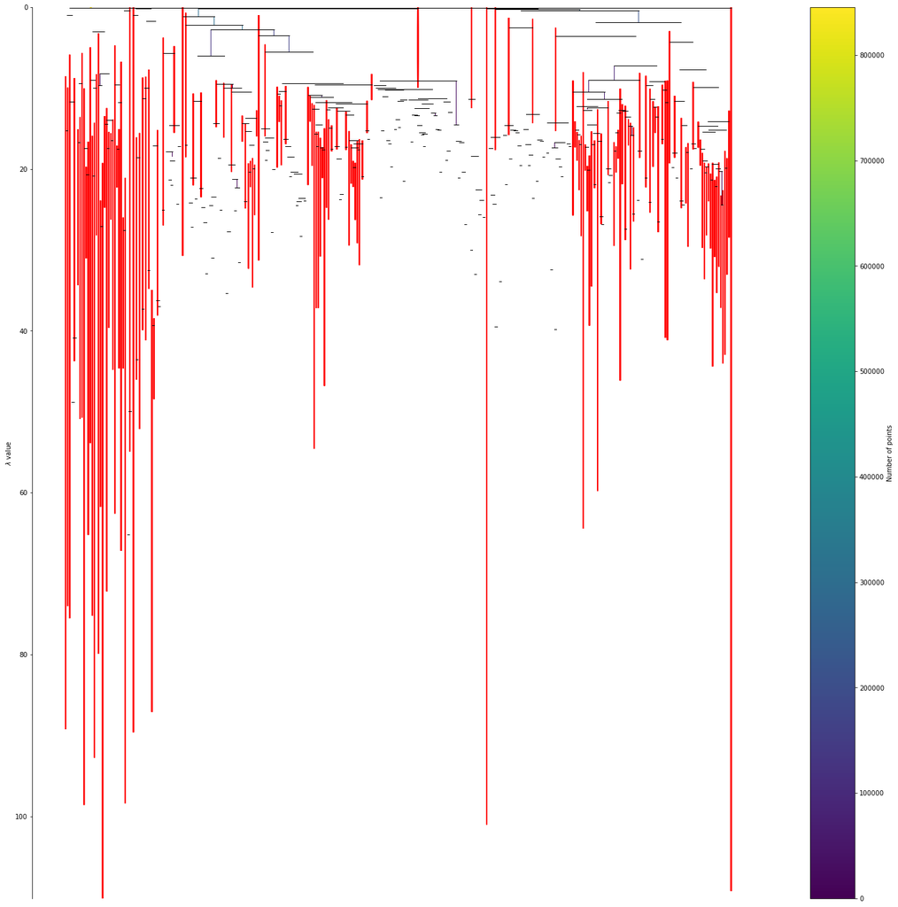

```python
plt.figure(figsize=(25,25))
hbdscan_fitted.condensed_tree_.plot(label_clusters=False, log_size=False, select_clusters=True,selection_palette=sns.color_palette("Set1", 13));
```

```python
%%time
# Caluculate Embeddings for customer dataset
customer_cluster_embeddings = umap_fitted.transform(customer_demographics_clean_sample.drop(columns=['Customer']).values)
del umap_fitted
# Determine Customer Clusters
customer_clusters = hdbscan.approximate_predict(hbdscan_fitted, customer_cluster_embeddings)
# Updated Clusters in customer dataset
customer_demographics_clean_sample['clusters'] = customer_clusters[0]
customer_demographics_clean_sample['clusters_prob'] = customer_clusters[1]


# Determine Population Clusters
clusters = hdbscan.approximate_predict(hbdscan_fitted, cluster_embedding)
del hbdscan_fitted
# Updated Clusters in Population dataset
population_demographics_clean_sample['clusters'] = clusters[0]
population_demographics_clean_sample['clusters_prob'] = clusters[1]

demographics_clean_sample_final = customer_demographics_clean_sample.append(population_demographics_clean_sample)
del customer_demographics_clean_sample, population_demographics_clean_sample
```

```
Wall time: 41min 40s
```

```python
%%time
# Evaluate segments created
cluster_labels = demographics_clean_sample_final.clusters.unique()

total_records = demographics_clean_sample_final.shape[0]
customer_prop_orig = demographics_clean_sample_final.Customer.mean()
cust_count_full = demographics_clean_sample_final.Customer.sum()
analysis_df = pd.DataFrame({'Cluster': ['All'], 'Not Customer': [(1-customer_prop_orig)*100], 'Customer': [customer_prop_orig*100], 'Per_Share_Customers': [cust_count_full*100/cust_count_full], 'Customer_Factor': [1], 'People_Count': [total_records]})

for cluster_ in cluster_labels:
    customer_prop = demographics_clean_sample_final.query("clusters == @cluster_").Customer.mean()
    cust_count = demographics_clean_sample_final.query("clusters == @cluster_").Customer.sum()
    people_count = demographics_clean_sample_final.query("clusters == @cluster_").Customer.sum()
    analysis_df = analysis_df.append({'Cluster': cluster_, 'Not Customer': (1-customer_prop)*100, 'Customer': customer_prop*100, 'Per_Share_Customers': cust_count*100/cust_count_full, 'Customer_Factor': customer_prop/customer_prop_orig, 'People_Count': people_count}, ignore_index=True)

analysis_df = analysis_df.sort_values(by=['Customer'], ascending=False)
```

```
Wall time: 19.5 s
```

```python
%%time
# Evaluate segments created
cluster_labels = demographics_clean_sample_final.clusters.unique()

total_records = demographics_clean_sample_final.shape[0]
customer_prop_orig = demographics_clean_sample_final.Customer.mean()
cust_count_full = demographics_clean_sample_final.Customer.sum()
analysis_df = pd.DataFrame({'Cluster': ['All'], 'Not Customer': [(1-customer_prop_orig)*100], 'Customer': [customer_prop_orig*100], 'Per_Share_Customers': [cust_count_full*100/cust_count_full], 'Customer_Factor': [1], 'People_Count': [total_records]})

for cluster_ in cluster_labels:
    customer_prop = demographics_clean_sample_final.query("clusters == @cluster_").Customer.mean()
    cust_count = demographics_clean_sample_final.query("clusters == @cluster_").Customer.sum()
    people_count = demographics_clean_sample_final.query("clusters == @cluster_").Customer.count()
    analysis_df = analysis_df.append({'Cluster': cluster_, 'Not Customer': (1-customer_prop)*100, 'Customer': customer_prop*100, 'Per_Share_Customers': cust_count*100/cust_count_full, 'Customer_Factor': customer_prop/customer_prop_orig, 'People_Count': people_count}, ignore_index=True)

analysis_df = analysis_df.sort_values(by=['Customer'], ascending=False)
```

```
Wall time: 50.5 s
```

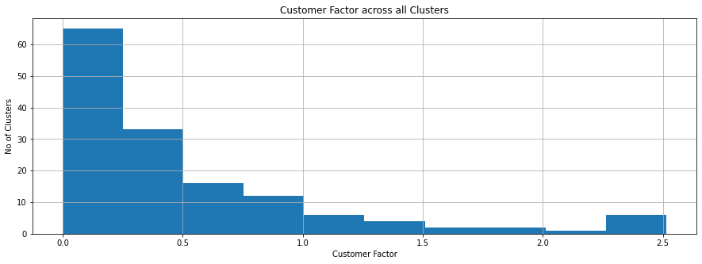

|  | Cluster | Not Customer | Customer | Per_Share_Customers | Customer_Factor | People_Count |
| --- | --- | --- | --- | --- | --- | --- |
| 7 | 17 | 62.117393 | 37.882607 | 1.402807 | 2.514202 | 5554.0 |
| 43 | 21 | 62.396694 | 37.603306 | 0.242691 | 2.495665 | 968.0 |
| 3 | 22 | 64.190043 | 35.809957 | 0.944761 | 2.376644 | 3957.0 |
| 8 | 10 | 64.435972 | 35.564028 | 10.697070 | 2.360322 | 45113.0 |
| 6 | 9 | 64.715511 | 35.284489 | 9.054905 | 2.341769 | 38490.0 |
| 34 | 25 | 65.581908 | 34.418092 | 0.416042 | 2.284268 | 1813.0 |
| 2 | 5 | 69.049974 | 30.950026 | 44.030403 | 2.054099 | 213373.0 |
| 55 | 12 | 72.846890 | 27.153110 | 0.302697 | 1.802104 | 1672.0 |
| 24 | 26 | 72.877493 | 27.122507 | 0.317365 | 1.800073 | 1755.0 |
| 23 | 44 | 74.408602 | 25.591398 | 0.158683 | 1.698456 | 930.0 |
| 31 | 30 | 76.743944 | 23.256056 | 1.491482 | 1.543463 | 9619.0 |
| 25 | 33 | 78.689610 | 21.310390 | 0.214688 | 1.414333 | 1511.0 |
| 19 | 51 | 79.175050 | 20.824950 | 0.138014 | 1.382115 | 994.0 |
| 47 | 29 | 80.499076 | 19.500924 | 0.140681 | 1.294242 | 1082.0 |
| 36 | 144 | 80.679785 | 19.320215 | 0.144014 | 1.282249 | 1118.0 |
| 26 | 13 | 81.290850 | 18.709150 | 0.152682 | 1.241693 | 1224.0 |
| 59 | 73 | 81.830791 | 18.169209 | 0.087342 | 1.205858 | 721.0 |
| 49 | 118 | 81.955923 | 18.044077 | 0.087342 | 1.197554 | 726.0 |
| 72 | 58 | 83.779264 | 16.220736 | 0.129346 | 1.076542 | 1196.0 |
| 48 | 77 | 83.922559 | 16.077441 | 0.127346 | 1.067031 | 1188.0 |
| 28 | 122 | 84.223559 | 15.776441 | 0.297363 | 1.047055 | 2827.0 |
| 0 | All | 84.932551 | 15.067449 | 100.000000 | 1.000000 | 995424.0 |

```python
analysis_df.Customer_Factor.hist(figsize=(15,5))
plt.xlabel("Customer Factor")
plt.ylabel("No of Clusters")
plt.title("Customer Factor across all Clusters")
plt.show()

analysis_df.head(22)
```

```python
class color:
    PURPLE = '\033[95m'
    CYAN = '\033[96m'
    DARKCYAN = '\033[36m'
    BLUE = '\033[94m'
    GREEN = '\033[92m'
    YELLOW = '\033[93m'
    RED = '\033[91m'
    BOLD = '\033[1m'
    UNDERLINE = '\033[4m'
    END = '\033[0m'
```

```python
clusters_above_general = analysis_df.query("Customer_Factor > 1")
clusters_with_double_customers = analysis_df.query("Customer_Factor > 2")

print(f"{clusters_with_double_customers.shape[0]} Clusters have {color.BOLD}double the number of customers relative to the base line{color.END} and capture about {color.BOLD}{clusters_with_double_customers.Per_Share_Customers.sum():.2f}%{color.END} of the customers of the customers from only {clusters_with_double_customers.People_Count.sum()/total_records*100:.2f}% of the Population")
print(f"{clusters_above_general.shape[0]} Clusters are above the base line and capture about {color.BOLD}{clusters_above_general.Per_Share_Customers.sum():.2f}%{color.END} of the customers from only {clusters_above_general.People_Count.sum()/total_records*100:.2f}% of the Population")

clusters_with_half_customers = analysis_df.query("Customer_Factor < 0.5")
clusters_below_general = analysis_df.query("Customer_Factor < 1")
print("")
print(f"{clusters_below_general.shape[0]} Clusters have less than the baseline and capture only {color.BOLD}{clusters_below_general.Per_Share_Customers.sum():.2f}%{color.END} of the customers from {clusters_below_general.People_Count.sum()/total_records*100:.2f}% of the Population")
print(f"{clusters_with_half_customers.shape[0]} Clusters have {color.BOLD}less than half the number of customers relative to the baseline{color.END} and capture only {color.BOLD}{clusters_with_half_customers.Per_Share_Customers.sum():.2f}%{color.END} of the customers from {clusters_with_half_customers.People_Count.sum()/total_records*100:.2f}% of the Population")
```

```
7 Clusters have double the number of customers relative to the base line and capture about 66.79% of the customers of the customers from only 31.07% of the Population
21 Clusters are above the base line and capture about 70.58% of the customers from only 33.74% of the Population

125 Clusters have less than the baseline and capture only 29.42% of the customers from 66.26% of the Population
97 Clusters have less than half the number of customres relative to the baseline and capture only 7.57% of the customers from 34.29% of the Population
```

```python
def plot_analysis_df():
    """
    This method plots data from the analysis dataframe

    :return: Cluster Chart and Cluster Count chart
    """
    viz_df = analysis_df.copy()
    bins = [-1, 0.5, 1, 2, np.inf]
    labels = ['0-0.5', '0.5-1', '1-2', '2+']

    viz_df['Customer_Factor_Categs'] = pd.cut(viz_df['Customer_Factor'], bins=bins, labels=labels).astype(str)
    base = alt.Chart(viz_df.iloc[:60])
    chart = base.mark_bar().encode(x=alt.X('Cluster', sort='-y'), y=alt.Y('Customer_Factor', title='Customer Factor'), color=alt.Color('Customer_Factor_Categs', title='Customer Factor Bin')).transform_filter(alt.datum.Cluster != 'All')
    rule = base.mark_rule(color='red').encode(y='Customer_Factor:Q').transform_filter(alt.datum.Cluster == 'All')
    chart1 = (chart + rule).properties(title='Customer Factor vs Top 60 Clusters')

    viz_df['Customer_Count'] = viz_df['People_Count']*viz_df['Customer']/100
    viz_df_temp = viz_df.query("Cluster != 'All'").groupby('Customer_Factor_Categs').agg({'Cluster': 'count',  'People_Count': 'sum', 'Customer_Count': 'sum'}).reset_index()
    viz_df_temp['People_Percentage'] = viz_df_temp['People_Count']/viz_df_temp['People_Count'].sum()
    viz_df_temp['Customer_Percentage'] = viz_df_temp['Customer_Count']/viz_df_temp['Customer_Count'].sum()

    base = alt.Chart(viz_df_temp).mark_circle(size=800)
    chart = base.encode(tooltip=['Cluster', 'People_Percentage', 'Customer_Percentage'] , y=alt.Y('Customer_Percentage', title='Customer Percentage', axis=alt.Axis(format='%')), size=alt.Size('Cluster:Q', title='No of Clusters', scale=alt.Scale(range=[100, 1000])), x=alt.X('People_Percentage', title='Population Percentage', axis=alt.Axis(format='%')), color=alt.Color('Customer_Factor_Categs', title='Customer Factor'))
    chart2 =chart.properties(title='Customer Perc vs Population Perc', width=400)

    base = alt.Chart(viz_df.query("Cluster != 'All'"))
    chart = base.mark_bar().encode(
        y=alt.Y('Customer_Factor_Categs', title='Customer Factor Bin', sort='x'),
        x=alt.X('count(Cluster)', title='No of Clusters'),
        color=alt.Color('Customer_Factor_Categs', title='Customer Factor Bin')
    ).properties(width=600, height=150, title='Histogram of Customer Factor')

    text = chart.mark_text(
        align='right',
        baseline='middle',
        dx= -5,  # Nudges text to right so it doesn't appear on top of the bar
        color='white' ,
        thickness=12
    ).encode(
        text='count(Cluster):Q',
        color=alt.value('white')
    )

    chart3 = chart + text

    return chart1, chart2, chart3
```

```python
chart1, chart2, chart3 = plot_analysis_df()
```

```python
chart1
```

[interactive chart not shown]

```python
chart2
```

[interactive chart not shown]

```python
chart3
```

[interactive chart not shown]

```python
demographics_clean_sample_final = pd.read_csv(processed_dir + "demographics_clean_sample_final.csv")
```

```python
# We save the demographics_clean_sample_final
demographics_clean_sample_final.to_csv(processed_dir + "demographics_clean_sample_final.csv", index=False)
analysis_df.to_csv(processed_dir + "cluster_analysis_df.csv", index=False)
```

## Evaluate Feature Importances

```python
random_seed = 22

all_columns = demographics_clean_sample_final.drop(columns=['Customer', 'clusters', 'clusters_prob']).columns.tolist()
# All columns not within the selected known set are considered ordinal or numerical columns
selected_known_columns = [col for col in all_columns if col in all_known_columns]
non_categ_features = numerical_features + ordinal_features
categ_features = [col for col in selected_known_columns if col not in non_categ_features]
```

```python
%%time
# Build Inferential Model to explain created Clusters
X_train, X_test, y_train, y_test = train_test_split(demographics_clean_sample_final.query("Customer == 0").drop(columns=['Customer','clusters', 'clusters_prob']), demographics_clean_sample_final.query("Customer == 0")['clusters'], test_size=0.33, random_state=random_seed)

# Train and Predict
lgbm = lgb.LGBMClassifier(random_state=random_seed, learning_rate=0.01, n_estimators=500, n_jobs=-1, verbose=1, objective='multiclass')\
    .fit(X_train, y_train, eval_set=[(X_test, y_test)], eval_metric='multi_logloss', early_stopping_rounds=20, feature_name=all_columns, categorical_feature=categ_features)
y_pred = lgbm.predict(X_test, num_iteration=lgbm.best_iteration_)
```

[output not shown]

[output not shown]

```
Overriding the parameters from Reference Dataset.
categorical_column in param dict is overridden.
```

[output not shown]

[output cut: 595 more lines]

[output not shown]

```python
print("Classification report for Inferential Model")
print(classification_report(y_test, y_pred, digits=3))
```

```
Classification report for Inferential Model
              precision    recall  f1-score   support

          -1      0.788     0.742     0.764     43827
           0      1.000     1.000     1.000       349
           1      0.994     0.986     0.990       512
           2      0.994     0.979     0.986       948
           3      0.988     0.995     0.992       770
           4      0.999     0.999     0.999      5644
           5      0.995     0.997     0.996     48612
           6      0.923     0.911     0.917       304
           7      0.880     0.872     0.876       219
           8      0.992     0.997     0.994      4893
           9      0.992     0.994     0.993      8256
          10      0.988     0.990     0.989      9481
```

[output cut: 138 more lines]

```python
%%time
# Explain Model using Shap
max_data_points = 50_000

explainer = shap.TreeExplainer(lgbm)
shap_values = explainer.shap_values(X_train[:max_data_points])
```

```
Wall time: 2h 1min 14s
```

```python
# Plot Summary Plot
def plot_cluster_summary_plot(cluster_no, no_of_features=5, plot_type='bar', shap_values=shap_values, X_train=X_train, max_data_points=max_data_points, all_columns=all_columns):
    """
    This method plots a summary plot for a single cluster

    :param cluster_no:
    :param no_of_features: No of features to plot
    :param plot_type:
    :param shap_values: Generated Shaply Values
    :param X_train:
    :param max_data_points:
    :param all_columns: List of column names that were in the training dataset
    :return: None
    """
    fig, axes = plt.subplots(1,1, figsize=(5, 5))

    shap.summary_plot(shap_values[cluster_no], X_train[:max_data_points], plot_type=plot_type, show=False, max_display=no_of_features, plot_size=(10, 5), feature_names=all_columns)
    axes.set_title(f"Cluster {np.arange(-1,145)[cluster_no]} Summary Plot")
    plt.show()
```

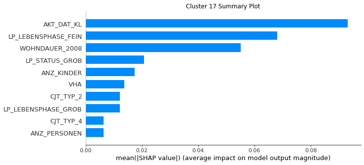

```python
plot_cluster_summary_plot(18, no_of_features=10)
```

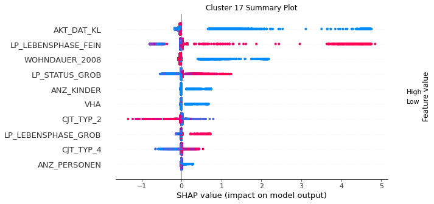

```python
plot_cluster_summary_plot(18, no_of_features=10, plot_type='dot')
```

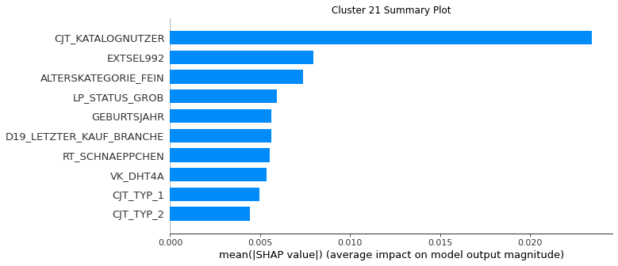

```python
plot_cluster_summary_plot(22, no_of_features=10)
```

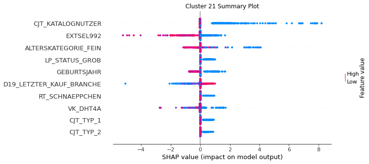

```python
plot_cluster_summary_plot(22, no_of_features=10, plot_type='dot')
```

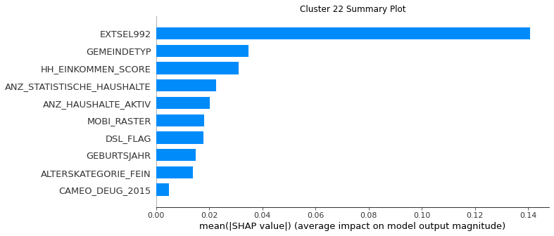

```python
plot_cluster_summary_plot(23, no_of_features=10)
```

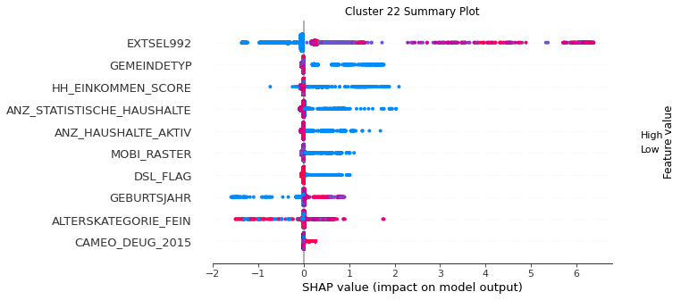

```python
plot_cluster_summary_plot(23, no_of_features=10, plot_type='dot')
```

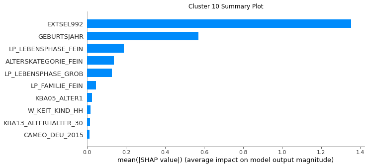

```python
plot_cluster_summary_plot(11, no_of_features=10)
```

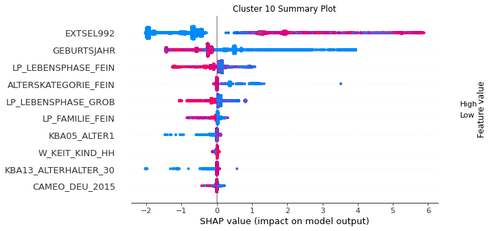

```python
plot_cluster_summary_plot(11, no_of_features=10, plot_type='dot')
```

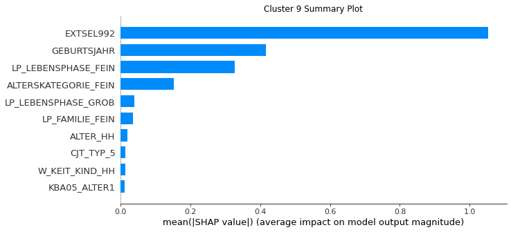

```python
plot_cluster_summary_plot(10, no_of_features=10)
```

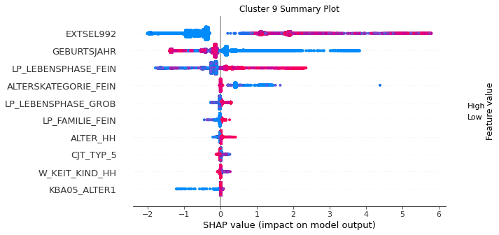

```python
plot_cluster_summary_plot(10, no_of_features=10, plot_type='dot')
```

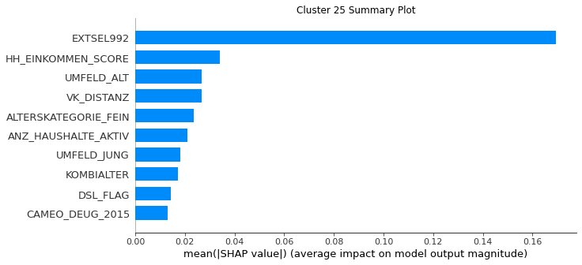

```python
plot_cluster_summary_plot(26, no_of_features=10)
```

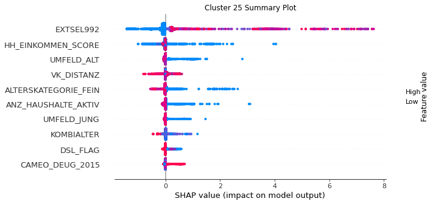

```python
plot_cluster_summary_plot(26, no_of_features=10, plot_type='dot')
```

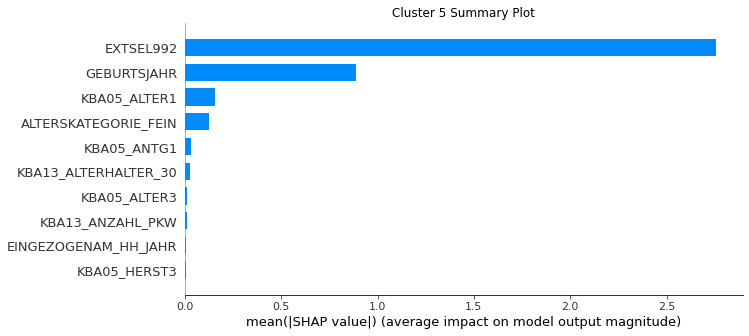

```python
plot_cluster_summary_plot(6, no_of_features=10)
```

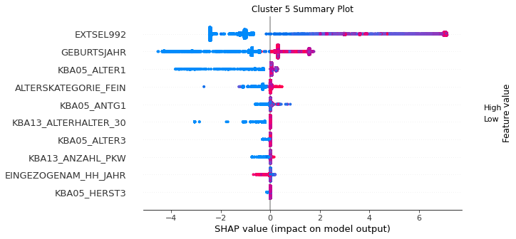

```python
plot_cluster_summary_plot(6, no_of_features=10, plot_type='dot')
```

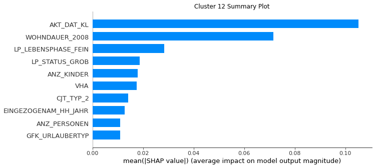

```python
plot_cluster_summary_plot(13, no_of_features=10)
```

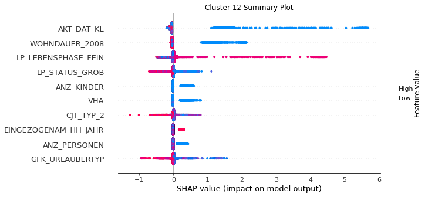

```python
plot_cluster_summary_plot(13, no_of_features=10, plot_type='dot')
```

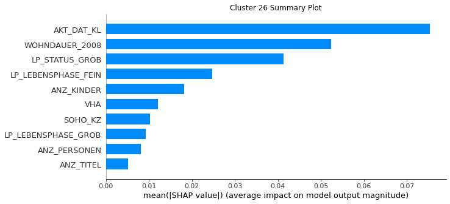

```python
plot_cluster_summary_plot(27, no_of_features=10)
```

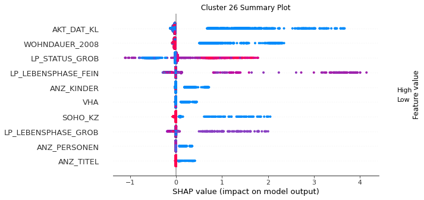

```python
plot_cluster_summary_plot(27, no_of_features=10, plot_type='dot')
```

```python
del explainer, shap_values
```

Comments: